```python
import pandas as pd
import matplotlib.pyplot as plt
import numpy as np
import altair as alt
from pylab import rcParams
rcParams['figure.figsize'] = 10, 10
import joypy
print('importing successful!')
```

```
importing successful!
```

For this assignment, I found a large (24691 rows!!) dataset that includes players since the 1950 season in the NBA. This dataset was extensive, and I only needed a few columns from this dataset. Altair also limits row count at 5000, so I thought 3000 rows was enough to give me the visualizations I was looking for.

# Main Question:

I wanted to find the 'prime years' of an NBA player. Now, 'prime' is very vague, and can be interpreted many differnt ways. I chose 'prime' to look at the most points scored per year. Below I will walk you through three different visualizations that answer my target question.

```python
df = pd.read_csv ('archive/Seasons_Stats.csv')
df1 = df[['Player', 'Age', 'PTS', 'FG%','Pos']]
df2 = df1.head(3000)
count_row = df.shape[0]  # Gives number of row
print(count_row)
```

```
24691
```

```python
df_pts = df.groupby(["Age"]).PTS.sum().reset_index()
alt.Chart(df_pts).mark_bar().encode(
    x='Age',
    y='PTS',
    # The highlight will be set on the result of a conditional
).properties(width=600)
```

[interactive chart not shown]

### Visualization 1:

This altair visualization shows the points scored (through the course of the season), grouped by player age. As clearly seen in the figure, players aged 24-27 are in their prime, when prime is described as the most points scored. A simple bar chart is required for this figure, where x axis is Age and Y axis is points.

```python
df3 = df2.head(100)
alt.Chart(df3).mark_point().encode(
    x = alt.X('Age', bin = True, scale=alt.Scale(domain=[20, 35])),
    y='PTS',
    size='FG%'
)
```

[interactive chart not shown]

### Visualization 2:

This is a very neat visualization. This is a bubble chart, that shows Age (on a scale of just 20-35), Points scored, and each players respective field goal percentage. This chart also shows a nice figure to help answer my main question. A players prime (points) is once again in the 24-27 range, however, there is a no signifigance between their age and their field goal percantage. This small sample shows me field goal percentage is not related to a players prime.

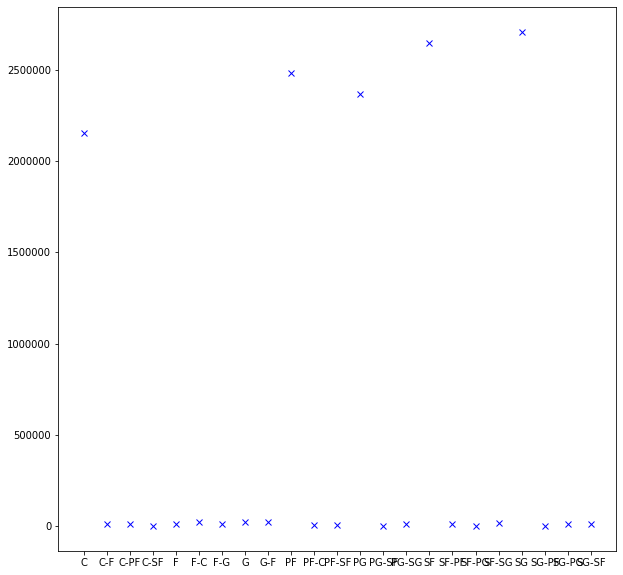

```python
df4 = df.groupby(["Pos"]).PTS.sum().reset_index()

x = df4['Pos']
y = df4['PTS']

plt.plot(x, y, 'x', color='blue');
```

### Visualization 3:

This last visualization shows the total points scored per position. As I was plotting, I thought 'maybe different positions score different points, Therefore my idea of points as a 'prime' indicator could be wrong?' I grouped the data by position, and as you can see, there is a difference in points scored based on position. All these points on the bottom are combinations of positions, for example if a player played power forward AND center. I chose to ignore these points and compare the 5 points at the top; PG, SG, SF, PF, and C - and there is an obvious point differential scored at these postions.